# Is Higher Altitude Associated with Higher Risk of Suicide?

Jim Pavlik

April 7, 2017

## Introduction

The other day, while I was distracted by a Facebook conversation with someone who can charitably be described as “comfortable with confirmation bias” in another subthread, a person posted a 2014 news story about a neurologist who thinks that elevation itself may be the cause of the disproportionately hight rates of suicide in the United States’ mountain west.<sup>1</sup>

Traditionally “the mountain west” is made up a Northwest region (Idaho, Montana, and Wyoming) and a Southwest region (Arizona, Nevada, New Mexico, Utah, and my homestate of Colorado. Respectively they rank 7th, 3rd, 1st, 12th, 8th, 4th, 5th, and 6th in the United States for highest suicide rates.<sup>2</sup> To say it another way, the 8 states of the mountain west are all top 12 states, and comprise 7 of the top 10 states. Alaska, Oregon, and Oklahoma are the non-“Mountain West” interlopers. And, of course, both Oregon and Alaska might considered mountainous and western, Alaska’s lack of contiguity and Oregon’s…hipsters(?) notwithstanding.

The nature of my other conversation sparked an interest in having a quick look at the data while giving me an opportunity to practice some R-fu.

# Data

## Suicide by County

The first step in the analysis was to get the data. Elevations of states, I thought, would be too broad. States like Colorado, for instance, have dramatic inclines in elevation. My house is right around 5,300 feet, but 30 minutes west, is Idaho Springs at 7,500 feet. And while I would love to get actual addresses, naturally vital records isn’t attaching such specific information to mortality data. Census block and tract would be too narrow to get reliable suicide data for most areas. So I looked for suicides by county. Interestingly, since the last time I looked into suicide data, the CDC has launched their interactive WISQARS site (https://wisqars.cdc.gov:8443/cdcMapFramework/). It has a lot of options, and it can make you a decent map of your query. Unfortunately, the `export to Excel` function is busted (or at least failed to create a file for me on either my Mac or PC machines). [I did make a map, by the way, but more on that in a bit.]

So I had to go elsewhere. And that elsewhere is the CDC Wonder site (https://wonder.cdc.gov/ucd-icd10.html.) Here I was able to get ahold of suicide data (ICD-10 X60-X84 “Intentional Self-Harm”) separated by county. I elected to get only 2015 data, which was problematic for the analysis, as we’ll see. I might return to this project later with something closer to what the WISQARS query would have provided.

Because the subsequent data file was too large to push to Github, you can replicate my search using the following criteria. 1. Group Results by `County` [I also elected to download the 95%CI but didn’t use them here]. Because I wanted single-year, county-level data, I also chose crude rates rather than the preferable age-adjusted rates. But for this analysis, I think that’s OK. 2. `All States` 3. `All Ages`, `All Genders`, `All Origins`, `All Races` 4. `2015` 5. `All Weekdays`, `Autopsy: All Values`, `Place of Death: All Places` 6. `Cause of Death: ICD-10 X60-X84`

This report was read into R.

## Elevation Data

The next step was to get data on the average elevation of each county. Luckily, the USGIS puts together a giant file with the elevations of several landmarks, structures, geographic entities…and counties. Unluckily, it is a gigantic file and I had to learn a whole bunch of things to make it useable. Which I guess was part of the point of this exercise. You can retrieve the data yourself here: https://geonames.usgs.gov/domestic/download_data.htm

This pipe-delimited data was also read into R:

### Removing unnecessary rows and columns from elevations dataset

Making the data usable really consisted of getting rid of most of the 2,000,000+ records I didn’t need, removing variables I didn’t need, and a few data transformations/coercions.

### Joining the Data

I was going to have to merge these two datasets, so I needed to make a common variable by which the right data from one could be joined with the right data from the other. The suicide dataset used a combined STATE_FIPS + COUNTY_FIPS variabe called `County.Code.` The elevation data set had both the state FIPS as numerical data and county FIPS codes as separate character data. Since `COUNTY_NUMERIC` was already a character variable, I was able to quickly add 0s to the front of each number (using `str_pad` from the stringr package) so that each observation consisted of three digits. In order to concatenate (using `paste`) `STATE_NUMERIC` to `COUNTY_NUMERIC` I had to coerce the first into character data. The resulting concatenation was named `County.Code` (using `mutate` from the dplyr package.)

## Missing Observations

Suicides, thankfully, are rare occurences. That is not to say it isn’t an important and growing problem, of course. Their rarity also means they are hard to get good information on for analysis. America has just over 3,000 counties and many of them are very sparsely populated and suicides themselves generally occur at the low rate of single-digits per 100,000 people. That means in any given year, most counties will not have any suicides, or they will have so few they are statistically indistinguishable from 0. The CDC, rather than report out unreliable data, chooses to suppress it. For my purposes, “suppressed” and “unreliable” were the same as missing data, so it’s easiest to convert them to NAs so I could `na.omit` to create my final dataset.

The final stage was to make sure that my variables were the right form for the regression. When reading in data, R frequently uses a default type of “factor.” Annoyingly, if one tries to coerce a factor directly into numeric, R assigns the observation the *rank* of the observation rather than its nominal value. This can be overcome by first coercing the factor into a character variable, and then into numeric.

```r
## Convert factor variables to numeric
deathEval$Deaths <- as.numeric(as.character(deathEval$Deaths))
deathEval$Population <- as.numeric(as.character(deathEval$Population))
deathEval$Crude.Rate <- as.numeric(as.character(deathEval$Crude.Rate))

deathEval2$Deaths <- as.numeric(as.character(deathEval2$Deaths))
deathEval2$Population <- as.numeric(as.character(deathEval2$Population))
deathEval2$Crude.Rate <- as.numeric(as.character(deathEval2$Crude.Rate))
```

Removing cases with missing data reduced the dataset from over 3,000 counties to 483. And, more than that, many of the counties that were lost are from higher elevations.

## Run and plot regression

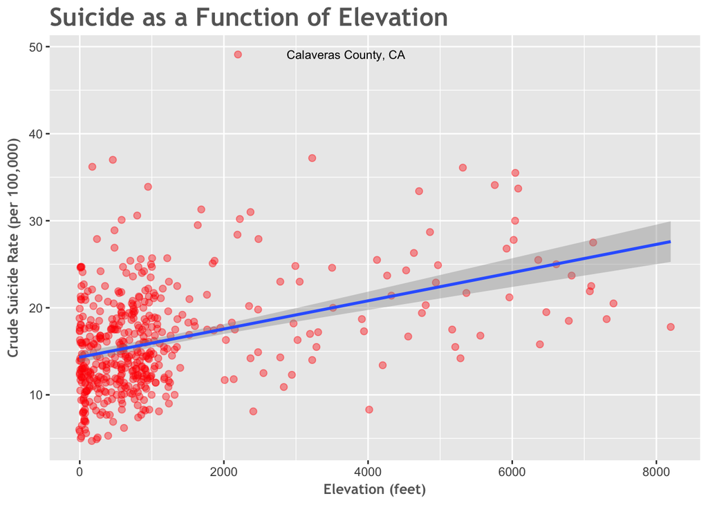

```
##
## Call:
## lm(formula = deathEval$Crude.Rate ~ deathEval$ELEV_IN_FT)
##
## Residuals:
##      Min       1Q   Median       3Q      Max
## -12.5282  -3.8602  -0.9469   3.1163  31.2223
##
## Coefficients:
##                       Estimate Std. Error t value Pr(>|t|)
## (Intercept)          1.432e+01  3.146e-01  45.521   <2e-16 ***
## deathEval$ELEV_IN_FT 1.620e-03  1.644e-04   9.857   <2e-16 ***
## ---
## Signif. codes:  0 '***' 0.001 '**' 0.01 '*' 0.05 '.' 0.1 ' ' 1
##
## Residual standard error: 5.563 on 481 degrees of freedom
## Multiple R-squared:  0.168,  Adjusted R-squared:  0.1663
## F-statistic: 97.16 on 1 and 481 DF,  p-value: < 2.2e-16
```

# Discussion

```
##
## Call:
## lm(formula = deathEval2$Crude.Rate ~ deathEval2$ELEV_IN_FT)
##
## Residuals:
##    Min     1Q Median     3Q    Max
## -2.037 -1.802 -1.786 -1.773 42.582
##
## Coefficients:
##                        Estimate Std. Error t value Pr(>|t|)
## (Intercept)           6.468e+00  1.157e-01  55.912   <2e-16 ***
## deathEval2$ELEV_IN_FT 2.289e-05  5.309e-05   0.431    0.666
## ---
## Signif. codes:  0 '***' 0.001 '**' 0.01 '*' 0.05 '.' 0.1 ' ' 1
##
## Residual standard error: 4.82 on 3073 degrees of freedom
## Multiple R-squared:  6.051e-05,  Adjusted R-squared:  -0.0002649
## F-statistic: 0.1859 on 1 and 3073 DF,  p-value: 0.6663
```

As with so many analyses of suicides, the lack of data both from a data gathering perspective and from the low rate of suicides themselves, leaves us significantly in the dark in determining true causes.

The final thing to note here is that, even if filling in missing cases with 4.7 unfairly hides a relationship that is there, this kind of study is only observational. Even if the relationship we found was twice as strong as the one shown in figure 1 above, *correlation does not equal causation*. It could very well be the case that elevation is proxying other conditions more directly related to suicide than physiological changes. The great plains states like Kansas and Wyoming and the mountainous states from Alaska to Utah are also rural and isolated. Many of the counties in question are poor precisely because they are rural and isolated. This rurality and isolation and poverty makes it hard and costly to extend critical mental health services into those areas. The lack of mental health services alone also contributes to a general culture that is skeptical if not opposed to mental health care. The stigma around care means that even when such services are available, they are not used. These counties are also known for cultures of rugged individualism and the US version of *machismo*. This not only contributes to the stigma around mental health care directly, it also actively encourages a “go it alone” strategy. It also contributes to US gun culture. And one thing that social science has made clear over the last 20 years or so is that guns are easily the most effective way to commit suicide with around 80% of attempts made with a guns being fatal.

# References

1. Fisher, T. (2014). There’s a suicide epidemic in Utah–And one neurologist thinks he knows why. Mic. url: https://mic.com/articles/104096/there-s-a-suicide-epidemic-in-utah-and-one-neuroscientist-thinks-he-knows-why#.V6NJE4HmA
2. CDC. (2014). Quickstats: Age-Adjusted Suicide Rates, by State–United States, 2012. url: https://www.cdc.gov/mmwr/preview/mmwrhtml/mm6345a10.htm